# Forecasting Physical Activity Across a Decade: A Machine Learning Exploration of Affect and Biopsychosocial Predictors

Final Project  
Data Science 2 with R (STAT 301-2)

Author

Angela Zhong

Published

February 16, 2026

**Github Repo Link**

[Angela’s Github Repo](https://github.com/stat301-2-2025-winter/final-project-2-Angelaaa-Z.git)

# Introduction

This project seeks to address a critical public health and clinical psychology question: how psychological states and baseline behaviors influence long-term physical activity patterns. By identifying predictors of sustained physical activity, the findings could inform interventions to promote healthier lifestyles. Additionally, this project contributes to a broader research effort that I’m working on, which focuses on exploring bidirectional relationships between physical activity and positive/negative affect over time.

# Data source

The data for this project comes from the **Midlife in the United States (MIDUS) study**, a longitudinal investigation of health and well-being in U.S. adults. The study began in 1995 (Time 1) and includes follow-ups at approximately 9-year intervals. This analysis uses the MIDUS Core sample from Time 2 (2004–2006) and Time 3 (2013–2014), which spans a 9-year observational period.

The MIDUS dataset is publicly accessible for research purposes[^1], with ethical approval and detailed methodology described in prior publications. The longitudinal design and inclusion of biopsychosocial variables make it well-suited for investigating predictors of long-term health behaviors.

<sup>1</sup> [MIDUS data documentation and access](https://www.midus.wisc.edu/data/index.php)

## Core Sample Overview

- **Time 2 (2004–2006)**: The Core sample included 4,963 participants (M = 55 years, SD = 12.4; 53% female; 90.1% White).
  - Physical activity: 77.51% of the Core sample (n = 4,963).
- **Time 3 (2013–2014)**: The Core sample retained 2,902 participants (M = 63.94 years, SD = 11.35; 55.9% female; 89.5% White), reflecting attrition over the 9-year interval.
  - Physical activity: 88.01% of the retained Core sample (n = 2,902).

## Target variable analysis

The total physical activity score at Time 3 is calculated by combining measurements across three intensity levels (light, moderate, vigorous), three activity types (job, chores, leisure), and two seasons (summer, winter). Participants reported their physical activity on a scale of 1 (several times a week) to 6 (never), with a higher score indicating fewer, less frequent physical activity. For each intensity-activity combination, the summer and winter scores are averaged with missing value handling. These averages are then combined to create subtotals for each intensity level (vigorous_total, moderate_total, light_total) by averaging across activity types. Finally, the total physical activity score is computed as the mean of these three intensity subtotals, providing a comprehensive measure of overall physical activity that accounts for all dimensions of the data.

### Physical Activity by Intensity and Season

Examining the subscores through Figure 1 reveals several patterns. Activity levels consistently differ across intensities, with vigorous activities showing the highest median scores (indicating less frequent activity), followed by moderate activities, and then light activities showing the lowest median scores (indicating more frequent activity). This pattern is intuitive as lighter activities tend to be more frequent in daily life. There are also seasonal variations, with lower median scores (indicating more frequent activity) in summer compared to winter for vigorous activities.

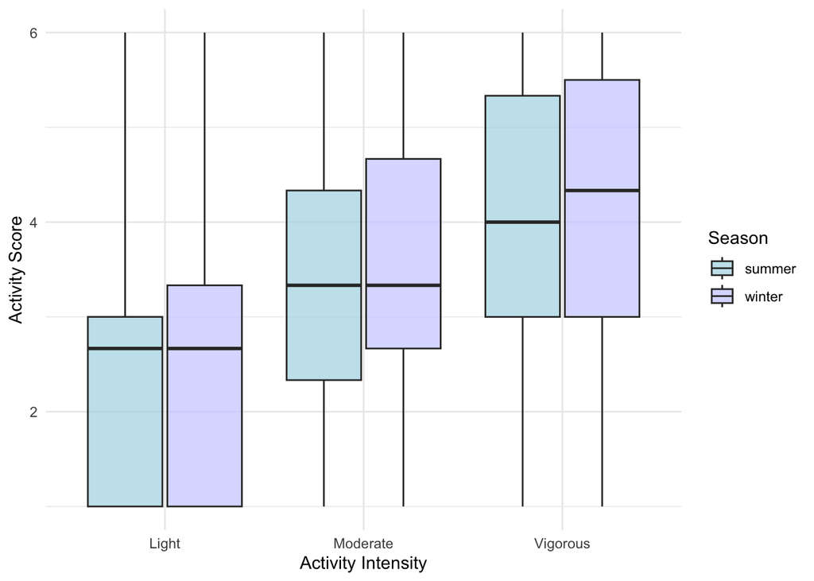

Figure 1: Physical Activity Levels by Intensity and Season

### Total Physical Activity Score

As shown in Figure 2, the total physical activity score distribution appears to be approximately normal, centered around a mean of 3.5 (red dashed line) which almost overlaps with the median (grey dashed line) - a characteristic of normal distributions. The histogram with density overlay shows a roughly bell-shaped pattern, with scores most concentrated in the middle range (3-4) and gradually decreasing frequencies toward both extremes. While there appears to be slightly more spread toward higher values (5-6, indicating less frequent activity) than lower values (1-2, indicating more frequent activity), this deviation from perfect normality is minor. Notably, the distribution shows a higher frequency of extreme low values (score of 1, indicating very frequent activity) compared to extreme high values (score of 6, indicating very infrequent activity). The roughly normal distribution suggests that most participants report moderate frequency of physical activity, with progressively fewer people reporting either very frequent or very infrequent physical activity - a pattern that is quite common in behavioral measures.

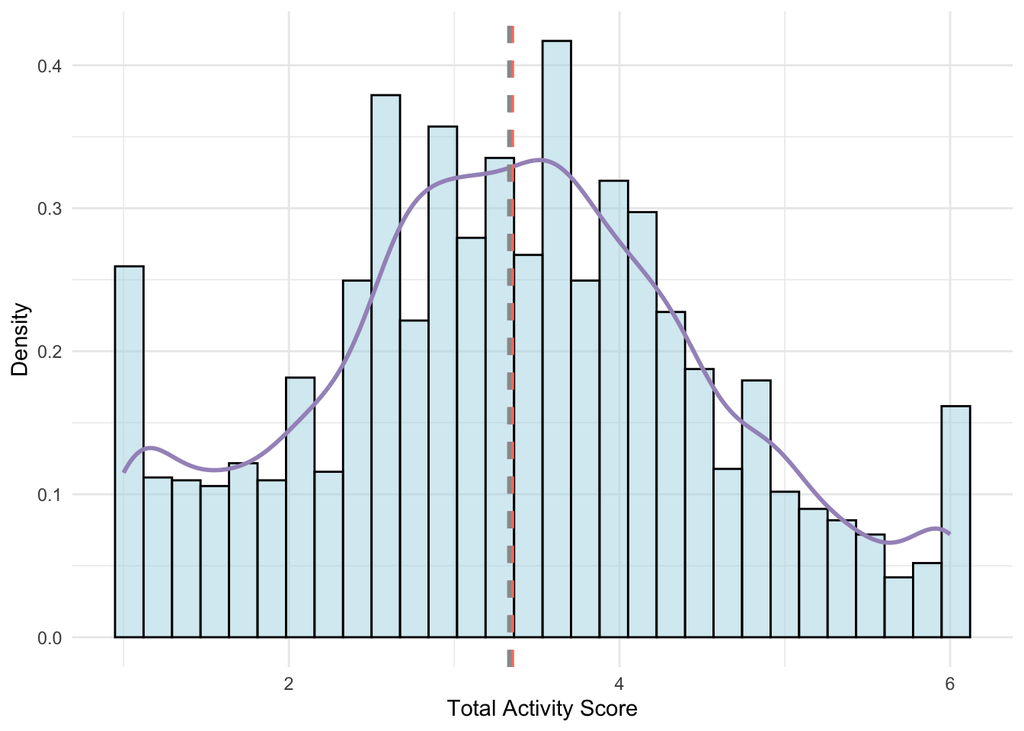

Figure 2: Distribution of Total Physical Activity Score

# Methods

## Predictors

- Baseline physical activity at Time 2
  - Total physical activity score—averaged across light, moderate, vigorous for summer/winter
- Affect at Time 2(based on PANAS, NAPAS; break down into 4 arousal-based predictors)
  - High-arousal positive affect (e.g., PANAS: “enthusiastic,” “active”)
  - Low-arousal positive affect (e.g., NAPAS: “calm,” “satisfied”)
  - High-arousal negative affect (e.g., PANAS: “jittery,” “upset”)
  - Low-arousal negative affect (e.g., NAPAS: “hopeless,” “lonely”)
- Demographics
  - Age (continuous)
  - Sex (binary: male/female)
- Health Status
  - BMI: Body Mass Index
  - Self-rated physical health
  - Self-rated health compared to others the same age
- Socioeconomic Status
  - Education level
  - Household income
- Psychological Factors
  - Self-evaluated mental health
  - Life satisfaction
  - Perceived stress (aggregated from PSS scale)

## Data Splitting

**Training/Testing Split**: 75% training, 25% testing. Stratified sampling will ensure proportional representation of sex across splits.

**Resampling**: 5-fold cross-validation on the training set to tune hyperparameters and evaluate performance. Cross-validation is preferred over bootstrap due to computational efficiency and the moderate sample size.

## Model Types & Tuning paramaters

**Null Model**

The null model serves as a baseline for comparison, predicting the mean physical activity score for all observations regardless of input features. This model provides a benchmark RMSE, representing the error if no predictors were used. No tuning is required for this model.

**Ordinary Linear Regression**

Ordinary linear regression models the relationship between predictors and the outcome as a linear combination of input features. It assumes additivity and linearity, making it a simple yet interpretable baseline. However, it may struggle with complex, non-linear relationships in the data. No tuning is required for this model.

**Elastic Net**

Elastic Net combines L1 (lasso) and L2 (ridge) regularization to handle multicollinearity and perform feature selection. It is particularly useful for datasets with correlated predictors, such as the affect subscales in MIDUS. The following parameters are tuned:

- Penalty (λ): Controls the overall strength of regularization.
- Mixture (α): Balances L1 and L2 penalties (α = 1 for lasso, α = 0 for ridge).

**Random Forest**

**Boosted Trees**

**Nearest Neighbors**

## Recipes

### Recipe 1 (Basic Preprocessing)

- Predictors
  - baseline physical activity (Time 2 total score)
  - four affect subscales (high-arousal positive, low-arousal positive, high-arousal negative, low-arousal negative)
  - demographics (age, sex)
  - health status (BMI, self-rated health)
  - socioeconomic factors (education, household income)
- Steps
  - replace missing numeric predictors (e.g., income, BMI) with their median values.
  - dummy encode categorical variables - convert sex (male/female) into a binary numeric variable (0/1)
  - normalize numeric predictors: scale and center all numeric variables (e.g., age, income) to mean = 0, SD = 1

### Recipe 2 (Interaction Terms)

- Predictors: All predictors in Recipe 1
  - Interactions between baseline physical activity and each affect subscale (e.g., baseline activity × high-arousal positive affect)
- Steps
  - impute missing values - same as Recipe 1
  - dummy encode categorical variable - same as Recipe 1
  - add interaction terms between baseline physical activity and the four affect subscales
  - normalize numeric predictors - same as Recipe 1

### Recipe 3 (High Arousal Emotions Only)

- Predictors
  - baseline physical activity (Time 2 total score)
  - two affect subscales (high-arousal positive, high-arousal negative)
  - demographics (age, sex)
  - health status (BMI, self-rated health)
  - socioeconomic factors (education, household income)
- Steps
  - replace missing numeric predictors (e.g., income, BMI) with their median values.
  - dummy encode categorical variables - convert sex (male/female) into a binary numeric variable (0/1)
  - normalize numeric predictors: scale and center all numeric variables (e.g., age, income) to mean = 0, SD = 1

## Assessment Metrics

The primary metric for evaluating model performance is **Root Mean Squared Error (RMSE)**, which quantifies the average deviation between predicted and observed values of physical activity. Along with Standard Error (SE), RMSE is particularly useful in this context for three reasons: - RMSE retains the original units of the outcome variable, making it easy to compare across models and assess practical significance. - Squaring residuals penalizes larger errors more heavily, ensuring models that consistently make large mistakes are appropriately downweighted. - RMSE enables direct comparison to the null model (which predicts the mean physical activity score) and across different modeling approaches, from simple regressions to tree-based methods.

Final model is assess based on RMSE, R², and MAE.

# Model Building & Selection Results

## Model Performance Overview

Table 1 summarizes the best-performing versions of each model-recipe combination, sorted by RMSE:

Table 1: Best Model-Recipe Combinations with Tuning Parameters

| Model | Recipe | Parameters | RMSE | SE |
| --- | --- | --- | --- | --- |
| Null | Basic | None | 1.221312 | 0.0087116 |
| Linear Regression | Basic | None | 1.043894 | 0.0069204 |
| Linear Regression | Interact | None | 1.046121 | 0.0069963 |
| Linear Regression | High | None | 1.043200 | 0.0068902 |
| Elastic Net | Basic | λ = 1, α = 0 | 1.071235 | 0.0070976 |
| Elastic Net | Interact | λ = 1, α = 0 | 1.055864 | 0.0070542 |
| Elastic Net | High | λ = 1, α = 0 | 1.071305 | 0.0071610 |
| Random Forest | Basic | trees = 812, mtry = 5, min_n = 50 | 1.055211 | 0.0056432 |
| Random Forest | Interact | trees = 812, mtry = 2, min_n = 50 | 1.058577 | 0.0060347 |
| Random Forest | High | trees = 437, mtry = 2, min_n = 50 | 1.053921 | 0.0059328 |
| Boosted Trees | Basic | trees = 100, tree_depth = 2, learn_rate = 1.012, loss_reduction = 10 | 1.078296 | 0.0073225 |
| Boosted Trees | Interact | trees = 100, tree_depth = 2, learn_rate = 1.012, loss_reduction = 10 | 1.089769 | 0.0062691 |
| Boosted Trees | High | trees = 100, tree_depth = 3, learn_rate = 1.012, loss_reduction = 10 | 1.082546 | 0.0067743 |
| K-Nearest Neighbors | Basic | neighbors = 10 | 1.136785 | 0.0088616 |
| K-Nearest Neighbors | Interact | neighbors = 10 | 1.146316 | 0.0073326 |
| K-Nearest Neighbors | High | neighbors = 10 | 1.127111 | 0.0087585 |

## Model Performance Analysis

**Null Model**  
The null model, which predicts the mean physical activity score for all observations, achieved an RMSE of 1.221 (SE = 0.009). This baseline serves as the critical threshold for evaluating model effectiveness. Any model failing to improve upon this value is considered ineffective.

**Linear Regression**  
Linear regression outperformed all other models across all recipes, with RMSE values between 1.043–1.046. The High recipe achieved the lowest RMSE (1.043), suggesting that high-arousal affect variables (e.g., “enthusiastic,” “jittery”) have a linear relationship with physical activity. This contrasts with expectations, as tree-based models typically dominate in biopsychosocial datasets.

**Elastic Net**  
Regularized regression underperformed compared to linear regression, with the best RMSE (1.056) in the Interact recipe. The optimal hyperparameters (λ = 1, α = 0) reduced the model to ridge regression, but this did not improve performance over simpler linear models. The lack of improvement suggests that multicollinearity was not a major issue or that regularization oversimplified the model.

**Random Forest**  
Random Forest achieved moderate performance, with the High recipe yielding the best RMSE (1.054). The optimal hyperparameters (trees = 437, mtry = 2, min_n = 50) indicate shallow trees with limited variable sampling, which may have restricted the model’s ability to capture complex patterns.

**Boosted Tree** Boosted Trees performed poorly (RMSE: 1.078–1.090), likely due to suboptimal hyperparameters: excessively high learn_rate = 1.012 (typical range: 0.01–0.3) and shallow tree_depth = 2–3, limiting non-linear feature interactions.

**K-Nearest Neighbors**  
KNN had the worst performance (RMSE: 1.127–1.146), indicating that local similarity patterns in the feature space provide little predictive signal for physical activity.

## Comparison between Recipes

**Interact Recipe**: Improved Elastic Net performance marginally (ΔRMSE = -0.015 vs. Basic recipe). Had negligible impact on other models, suggesting interaction terms were either redundant or already captured by tree-based methods.

## Final Model Selection

The **Linear Regression with the High recipe** (RMSE = 1.043) was selected as the final model. This decision is justified by:

1. **Performance**: It achieved the lowest RMSE across all models, reducing prediction error by 14.6% compared to the null model (ΔRMSE = 0.178).
2. **Simplicity**: Linear regression’s outperformance of tree-based models suggests the relationships between predictors and physical activity are predominantly linear.
3. **Theoretical Alignment**: The High recipe’s focus on high-arousal affect matches established psychological frameworks linking energetic states to health behaviors.

# Final Model Analysis

Table 2: Final Model Performance on Test Set

| Metric | Estimate |
| --- | --- |
| rmse | 1.0631 |
| rsq | 0.2315 |
| mae | 0.8415 |

To further assess the model’s performance, a scatterplot comparing predicted vs. actual physical activity scores (Figure 3) was generated. While there is a general positive correlation along the y = x line, the spread of points suggests variability in the model’s predictive accuracy. Some underestimation and overestimation patterns are noticeable, particularly at higher values of physical activity scores.

While the linear regression with high-arousal emotions only model outperformed alternative models, its explanatory power is limited. The modest R² value suggests that other unmodeled factors influence physical activity scores. Future work could explore additional predictors, interaction terms, or non-linear modeling techniques to enhance predictive accuracy.

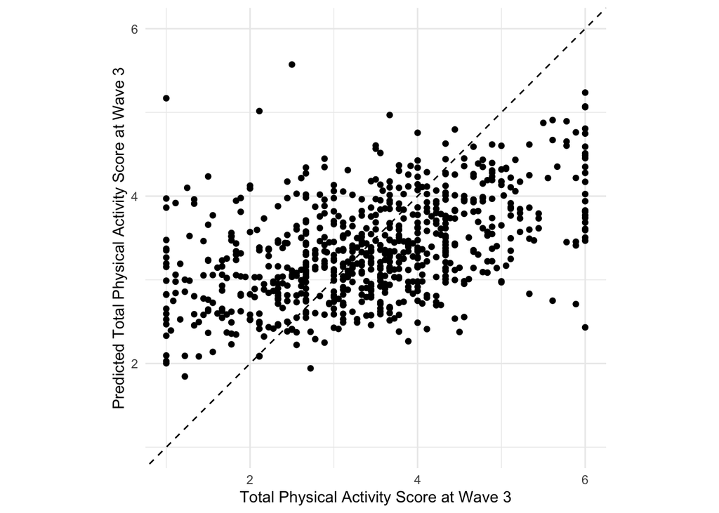

Figure 3: Predicted Vs. Actual Physical Activity

# Conclusion

This study leveraged longitudinal data from the Midlife in the United States (MIDUS) cohort to predict physical activity patterns over a 9-year period (2004–2014) using biopsychosocial predictors measured at baseline. Focusing on 2,902 participants with complete data, the analysis tested six machine learning models across three feature-engineered recipes to evaluate the predictive power of high- and low-arousal emotions, demographics, health metrics, and socioeconomic factors. The simplicity of linear regression unexpectedly outperformed complex models like Random Forest, with the High-arousal recipe (prioritizing energetic emotional states) emerging as the most effective.

The superiority of a simple linear regression model over more complex methods like Random Forest challenges assumptions about the necessity of non-linear modeling for biopsychosocial data, suggesting that linear relationships dominate in this context. The final model’s moderate performance (R² = 0.232) underscores the multifactorial nature of physical activity, with factors beyond affect—such as environmental, genetic, or unmeasured behavioral variables—likely playing significant roles.

While the model’s performance is modest, its interpretability and alignment with psychological theory make it a valuable tool for generating hypotheses and guiding future research. The findings reinforce the importance of emotional states in health behavior and highlight the need for holistic approaches to physical activity promotion.It also provides actionable insights for public health interventions. For example, programs targeting emotional regulation or enthusiasm-building could indirectly promote physical activity.

**Future Directions**

- Expand Predictors: Incorporate additional variables (e.g., social support, neighborhood walkability) to improve explanatory power.
- Non-Linear Exploration: Test spline terms or interaction effects within the linear framework to capture subtle non-linearities.
- Longitudinal Analysis: Model changes in affect and physical activity over time using mixed-effects or growth curve models.
- Intervention Design: Use the identified high-arousal affect predictors to pilot targeted behavioral interventions (e.g., enthusiasm-boosting programs).

# Appendix: Hyperparameter Tuning Graphs

## Elastic Net

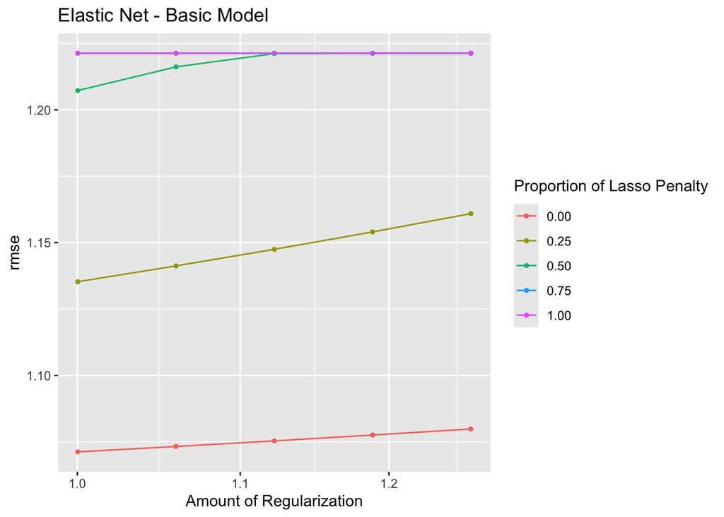

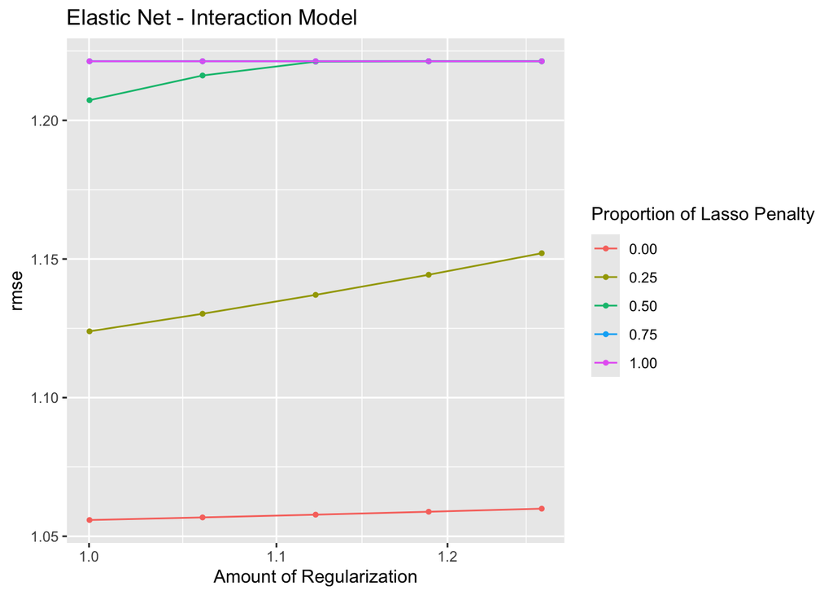

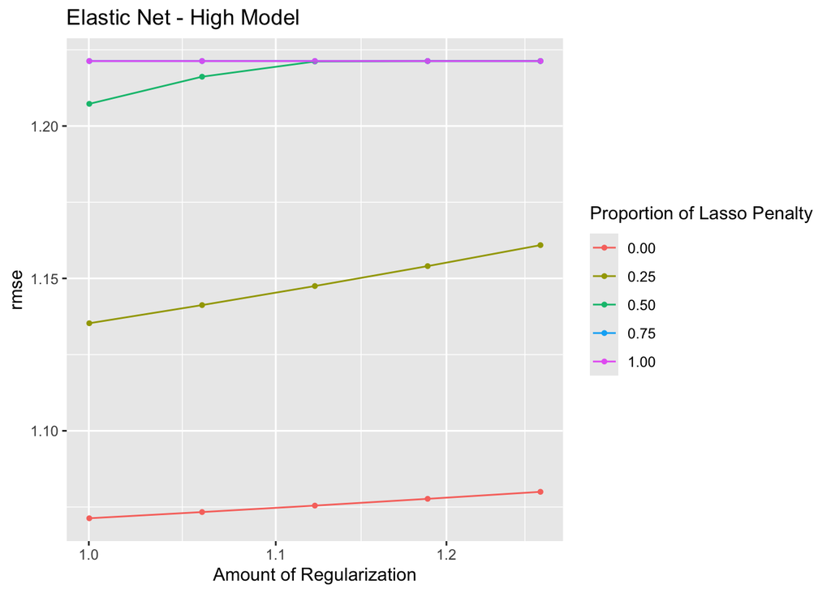

## Nearest Neighbor

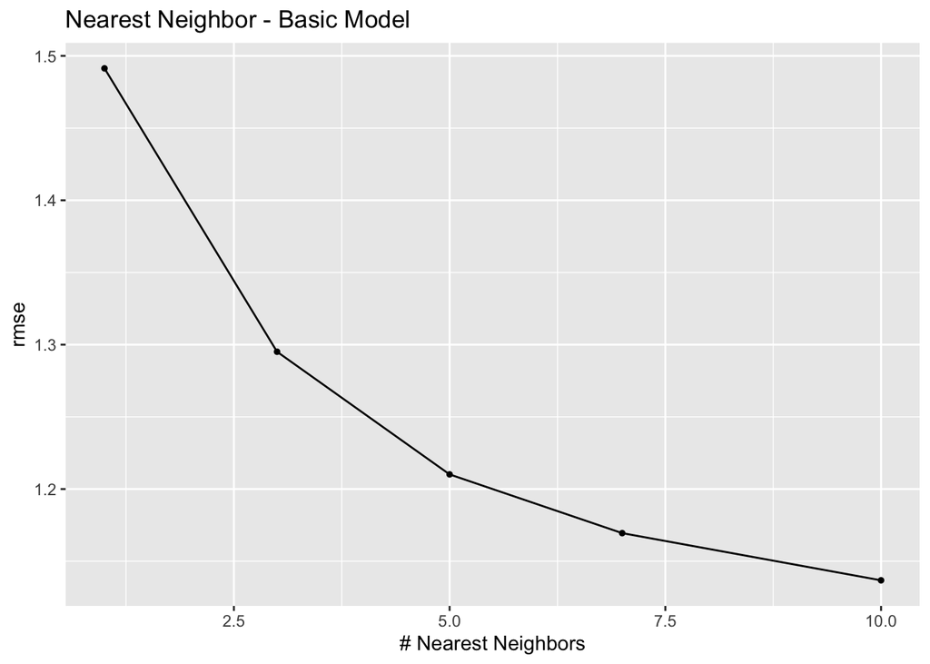

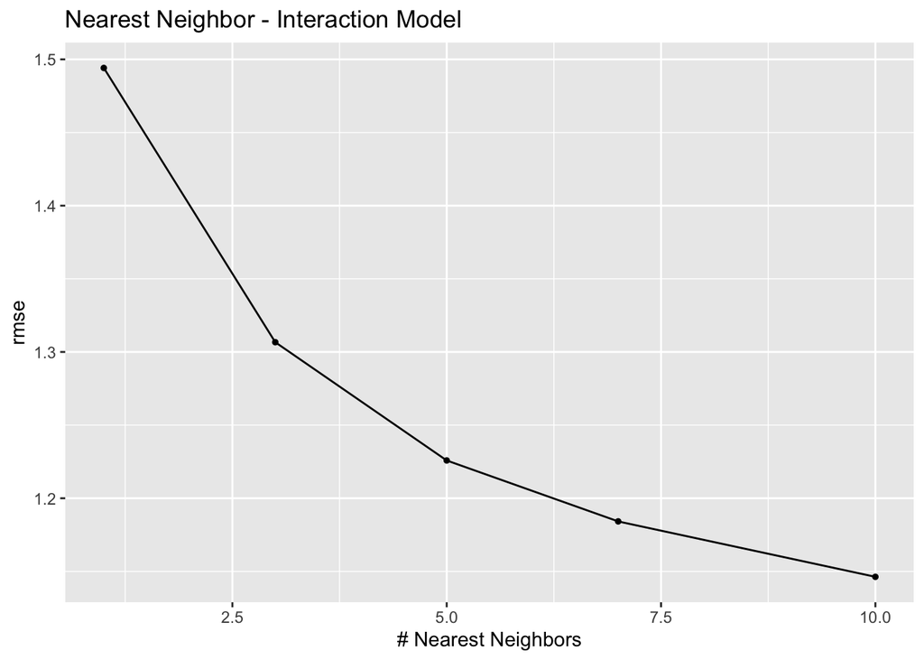

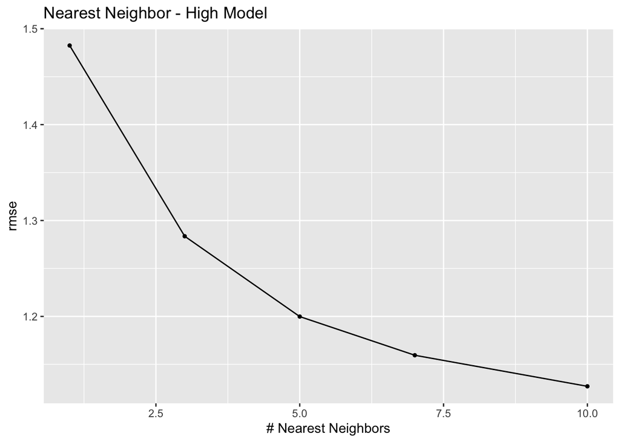

## Random Forest

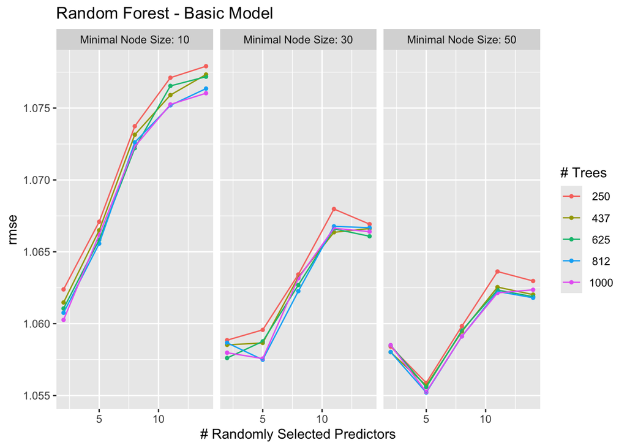

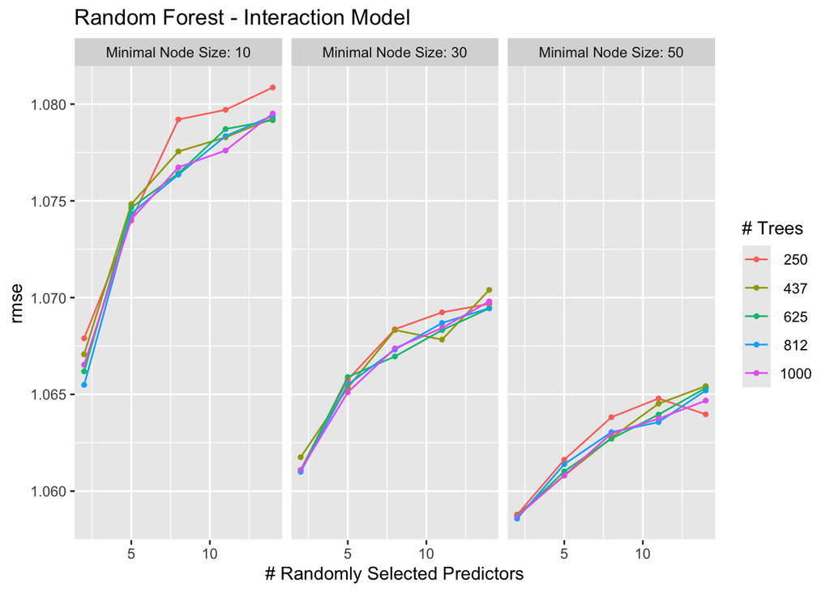

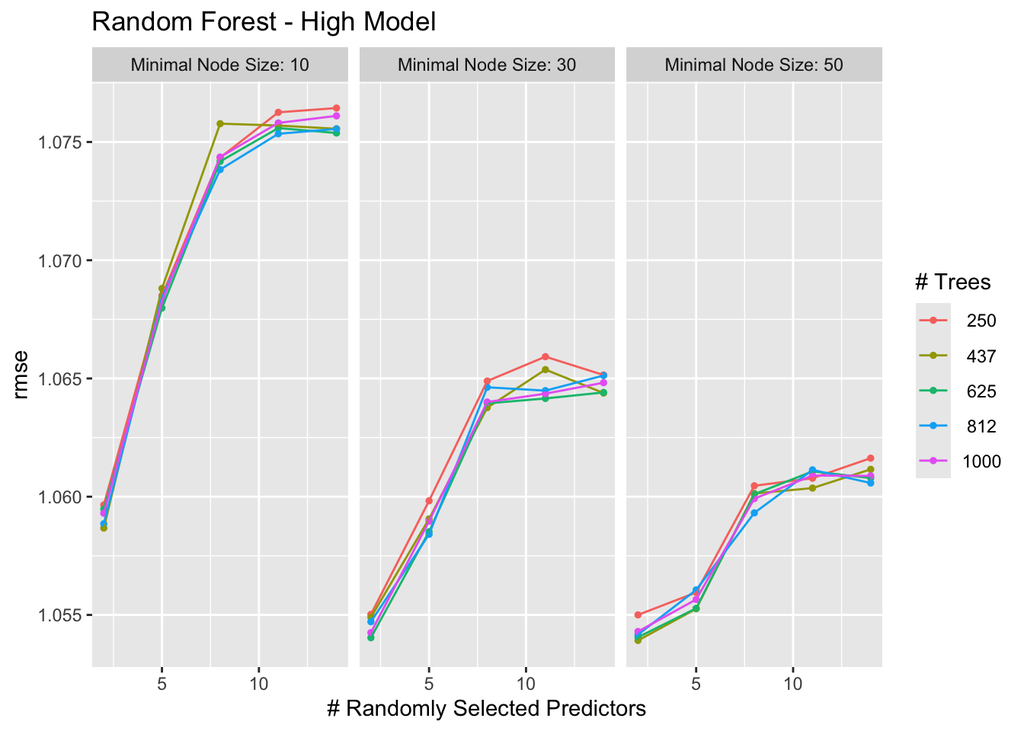

## Boosted Trees

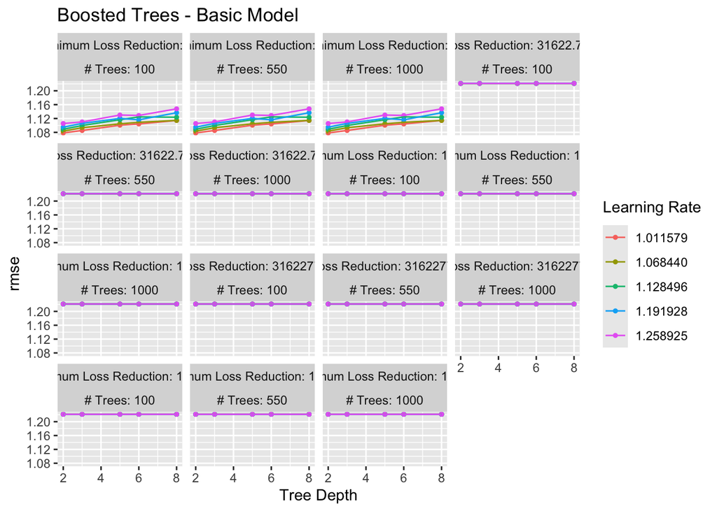

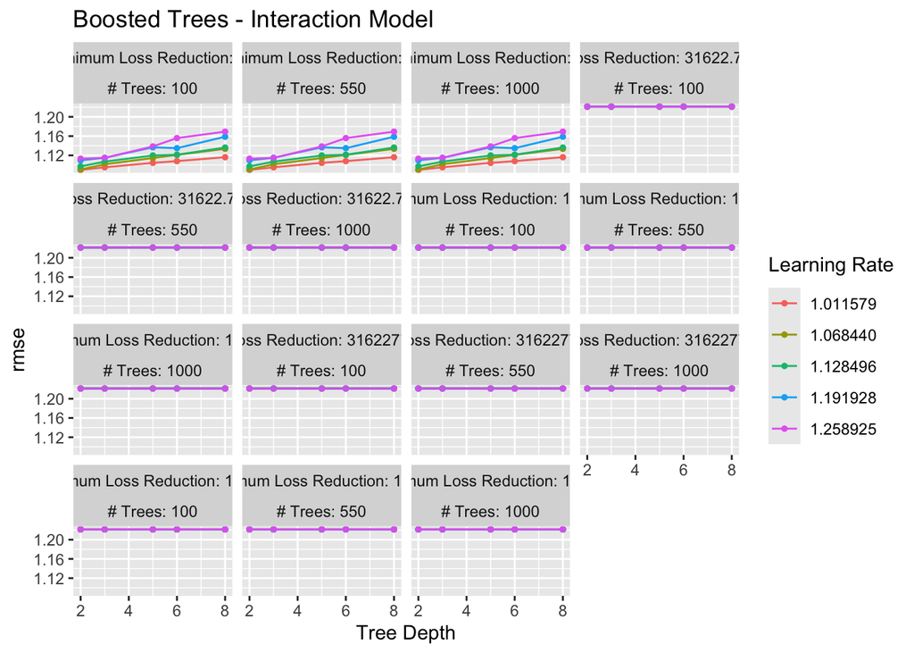

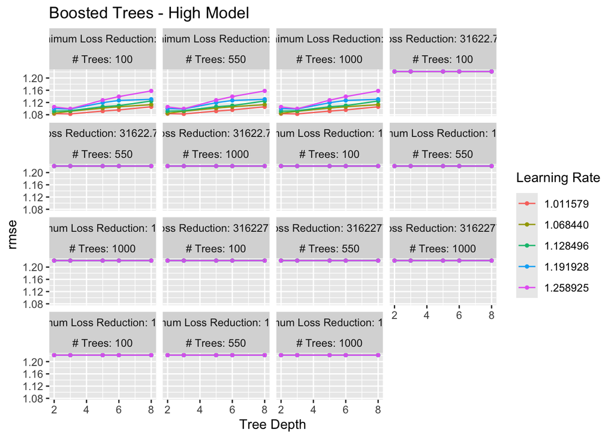